# 452_Assignment_1

#### **Question 9**

Why false discoveries might be problematic here?

Theoretically, there are too many variables (52 to be exact) in the model. Some coefficients could be statistically significant due to chance. From the model summary, there are 27 significant values. But as we will identify with the BH procedure in the next question, there are only 19 truly significant variables. That’s 8 variables the test has falsly discovered as significant.

Practically, if management make conclusion based on this discovery and establish policy and investment around falsely meaningful variables, it could lead to heavy loses and negative outcomes.

#### **Question 10**

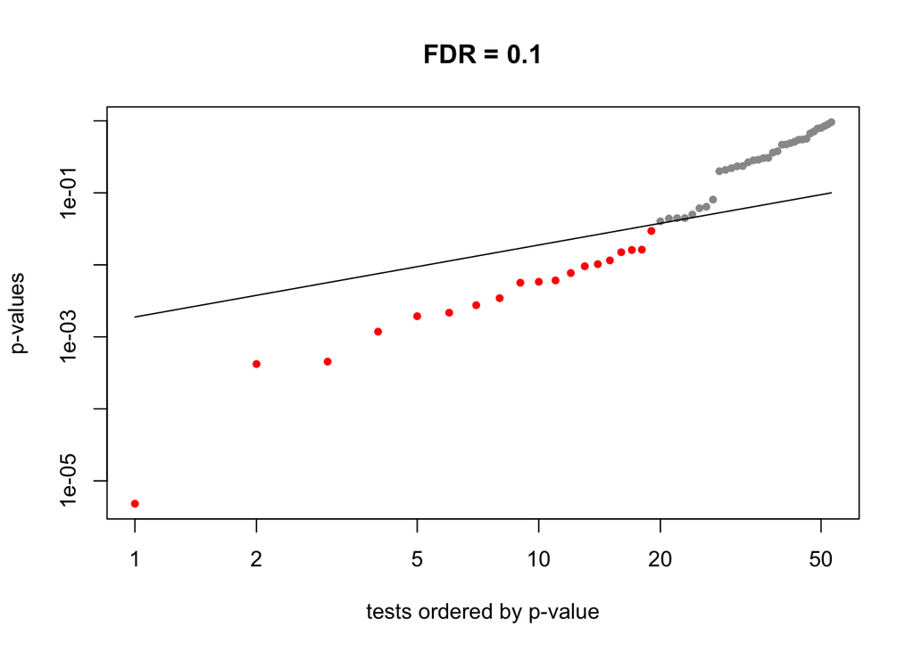

```
## [1] 0.02956354
```

```r
# extracting the p-values from the model with all variables - prediction4
p_vals <- summary(prediction4)$coefficients[,4]

fdr(p_vals, 0.1, plotit = TRUE)
```